# test MaCSTS 2

## General Notes

As mentioned in `test MaCSTS 1`, when `useMacsMut = FALSE`, even ancestry (trees without mutation) from MaCSTS can differ from MaCS because of RNG state changes. So here, we can only focus on the comparison on distributions (e.g. tree height, numbers of mutations, nodes and edges). This notebook runs MaCSTS with `useMacsMut = FALSE` to generate ancestry-only tree sequences across multiple scenarios and replicates, then applies post-TS mutation separately.

## Goal Of This Notebook

This notebook runs `MaCSTS(..., useMacsMut = FALSE)` across multiple scenarios, with multiple replicates per scenario. The mutation distributions and other statistics against legacy MaCS outputs will be compared, the CSV files record the seeds, paths and parameters for all runs; the .trees files will be output, enabling downstream analysis in Python/tskit to compare the distributions about trees and mutations, against msprime simulations.

Output:

1. `.trees` files per replicate/chromosome
2. a minimal manifest (`CSV`) listing scenario/rep/chromosome/seed/path

When `applyPostMut = TRUE`, it also applies post-TS mutation using `tsMutateTableCollection()` with mutation rate `dTheta = seqLen * (-t)` from args.

## Configuration

```r
library(AlphaSimR)
library(RcppTskit)

# Safe param getter so chunks also run interactively (without rmarkdown::render).
get_param <- function(name, default) {
  if (exists("params", inherits = TRUE) &&
      is.list(params) &&
      !is.null(params[[name]])) {
    return(params[[name]])
  }
  default
}

nRep <- as.integer(get_param("nRep", 50L))
nChr <- as.integer(get_param("nChr", 1L))
inbred <- isTRUE(get_param("inbred", FALSE))
ploidy <- as.integer(get_param("ploidy", 2L))
nThreads <- as.integer(get_param("nThreads", 1L))
usePhysicalPositions <- isTRUE(get_param("usePhysicalPositions", TRUE))
Nref <- as.numeric(get_param("Nref", 10000))
baseSeed <- as.integer(get_param("baseSeed", 700000L))
outDir <- as.character(get_param("outDir", "out_phase1_useMacsMut_FALSE"))
writeTrees <- isTRUE(get_param("writeTrees", TRUE))
applyPostMut <- isTRUE(get_param("applyPostMut", TRUE))
mutSeedOffset <- as.integer(get_param("mutSeedOffset", 0L))

if (nRep <= 0L) stop("nRep must be positive.")
if (nChr <= 0L) stop("nChr must be positive.")
if (ploidy <= 0L) stop("ploidy must be positive.")

dir.create(outDir, recursive = TRUE, showWarnings = FALSE)
```

## Scenario Set

```r
# Keep scenarios connected in multi-pop cases (migration and/or join),
# so runs always finish.
scenarios <- list(
  list(
    id = 1L,
    name = "single_const",
    args = "8 100000 -t 1e-3 -r 1e-4 -s "
  ),
  list(
    id = 2L,
    name = "single_eN",
    args = "8 100000 -t 1e-3 -r 1e-4 -eN 0.2 2.0 -eN 1.0 0.5 -s "
  ),
  list(
    id = 3L,
    name = "I2_migration",
    args = "8 100000 -t 1e-3 -r 1e-4 -I 2 4 4 1e-2 -eM 0.5 5e-3 -ej 1.0 2 1 -s "
  ),
  # -I 2 4 4 1e-2: two populations, 4+4 sampled, with initial migration.
  #-en 0.2 2 0.5: pop 2 becomes smaller at time 0.2.
  #-ej 1.0 2 1: at time 1.0, pop 2 joins pop 1 backward (equivalent to a forward split).
  list(
    id = 4L,
    name = "I2_en_join",
    args = "8 100000 -t 1e-3 -r 1e-4 -I 2 4 4 1e-2 -en 0.2 2 0.5 -ej 1.0 2 1 -s "
  )
)

scenario_df <- do.call(
  rbind,
  lapply(scenarios, function(s) data.frame(id = s$id, name = s$name, args = s$args))
)
scenario_df
```

```
##   id         name
## 1  1 single_const
## 2  2    single_eN
## 3  3 I2_migration
## 4  4   I2_en_join
##                                                                   args
## 1                                         8 100000 -t 1e-3 -r 1e-4 -s
## 2                 8 100000 -t 1e-3 -r 1e-4 -eN 0.2 2.0 -eN 1.0 0.5 -s
## 3  8 100000 -t 1e-3 -r 1e-4 -I 2 4 4 1e-2 -eM 0.5 5e-3 -ej 1.0 2 1 -s
## 4 8 100000 -t 1e-3 -r 1e-4 -I 2 4 4 1e-2 -en 0.2 2 0.5 -ej 1.0 2 1 -s
```

## Helpers

```r
make_seed_vec <- function(scenario_id, rep_id, nChr, baseSeed) {
  # Deterministic integer seed vector, one seed per chromosome.
  as.integer(baseSeed + scenario_id * 100000L + rep_id * 1000L + seq_len(nChr) - 1L)
}

parse_dTheta <- function(args) {
  tok <- strsplit(as.character(args), "[,[:space:]]+", perl = TRUE)[[1L]]
  tok <- tok[nzchar(tok)]
  if (length(tok) < 2L) stop("args must include sample size and sequence length.")
  seqLen <- as.numeric(tok[2L])
  if (!is.finite(seqLen) || seqLen <= 0) stop("Invalid sequence length in args.")
  i_t <- match("-t", tok)
  if (is.na(i_t) || i_t >= length(tok)) return(0)
  tval <- as.numeric(tok[i_t + 1L])
  if (!is.finite(tval) || tval < 0) stop("Invalid -t value in args.")
  seqLen * tval
}

run_one <- function(sc, rep_id) {
  seed_vec <- make_seed_vec(sc$id, rep_id, nChr, baseSeed)
  dTheta <- parse_dTheta(sc$args)
  mut_seed_vec <- as.integer(seed_vec + mutSeedOffset)

  out <- AlphaSimR:::MaCSTS(
    args = sc$args,
    nChr = nChr,
    inbred = inbred,
    ploidy = ploidy,
    nThreads = nThreads,
    seed = seed_vec,
    usePhysicalPositions = usePhysicalPositions,
    useMacsMut = FALSE,
    Nref = Nref
  )
  timeScale <- as.numeric(out$timeScale)
  if (!is.finite(timeScale) || timeScale <= 0) {
    stop("Invalid timeScale returned by MaCSTS.")
  }
  # MaCS dTheta is in coalescent-time units.
  # If MaCSTS times were rescaled (e.g., to generations), adjust theta accordingly.
  dTheta_post <- dTheta / timeScale
  # Legacy MaCS run with identical args/seeds for mutation-count reference.
  macs <- AlphaSimR:::MaCS(
    args = sc$args,
    maxSites = rep(0L, nChr),
    inbred = inbred,
    ploidy = ploidy,
    nThreads = nThreads,
    seed = seed_vec
  )

  rows <- vector("list", nChr)
  for (chr in seq_len(nChr)) {
    tc_xptr <- out$tables[[chr]]
    if (applyPostMut && dTheta_post > 0) {
      AlphaSimR:::tsMutateTableCollection(tc_xptr, dTheta_post, as.numeric(mut_seed_vec[chr]))
    }
    tc <- RcppTskit::TableCollection$new(xptr = tc_xptr)
    ts <- tc$tree_sequence()
    tc_summary <- AlphaSimR:::rtsk_table_collection_summary2(tc_xptr)

    tree_path <- NA_character_
    if (writeTrees) {
      tree_path <- file.path(
        outDir,
        sprintf("%s_rep%02d_chr%02d.trees", sc$name, rep_id, chr)
      )
      ts$write(tree_path)
    }

    rows[[chr]] <- data.frame(
      scenario_id = sc$id,
      scenario = sc$name,
      rep = rep_id,
      chr = chr,
      args = sc$args,
      seed_chr = seed_vec[chr],
      mut_seed_chr = mut_seed_vec[chr],
      dTheta = dTheta,
      dTheta_post = dTheta_post,
      usePhysicalPositions = usePhysicalPositions,
      Nref = Nref,
      macs_num_mutations = as.numeric(length(macs$genMap[[chr]])),
      macsts_num_mutations = as.numeric(tc_summary$num_mutations),
      tree_path = tree_path,
      stringsAsFactors = FALSE
    )
  }

  do.call(rbind, rows)
}
```

## Run Replicates

```r
manifest_rows <- vector("list", length(scenarios) * nRep)
status_rows <- vector("list", length(scenarios) * nRep)
k <- 0L

for (sc in scenarios) {
  for (rep_id in seq_len(nRep)) {
    k <- k + 1L
    run_label <- sprintf("%s rep%02d", sc$name, rep_id)
    cat("Running:", run_label, "\n")

    err_msg <- NA_character_
    one <- tryCatch(
      run_one(sc, rep_id),
      error = function(e) {
        err_msg <<- conditionMessage(e)
        NULL
      }
    )

    manifest_rows[[k]] <- one
    status_rows[[k]] <- data.frame(
      scenario_id = sc$id,
      scenario = sc$name,
      rep = rep_id,
      success = !is.null(one),
      error = ifelse(is.na(err_msg), "", err_msg),
      stringsAsFactors = FALSE
    )
  }
}
```

```
## Running: single_const rep01
## Running: single_const rep02
## Running: single_const rep03
## Running: single_const rep04
## Running: single_const rep05
## Running: single_const rep06
## Running: single_const rep07
## Running: single_const rep08
## Running: single_const rep09
## Running: single_const rep10
## Running: single_const rep11
## Running: single_const rep12
## Running: single_const rep13
## Running: single_const rep14
## Running: single_const rep15
## Running: single_const rep16
## Running: single_const rep17
## Running: single_const rep18
## Running: single_const rep19
## Running: single_const rep20
## Running: single_const rep21
## Running: single_const rep22
## Running: single_const rep23
## Running: single_const rep24
## Running: single_const rep25
## Running: single_const rep26
## Running: single_const rep27
## Running: single_const rep28
## Running: single_const rep29
## Running: single_const rep30
## Running: single_const rep31
## Running: single_const rep32
## Running: single_const rep33
## Running: single_const rep34
## Running: single_const rep35
## Running: single_const rep36
## Running: single_const rep37
## Running: single_const rep38
## Running: single_const rep39
## Running: single_const rep40
```

[output cut: 145 more lines]

```
## Running: I2_en_join rep36
## Running: I2_en_join rep37
## Running: I2_en_join rep38
## Running: I2_en_join rep39
## Running: I2_en_join rep40
## Running: I2_en_join rep41
## Running: I2_en_join rep42
## Running: I2_en_join rep43
## Running: I2_en_join rep44
## Running: I2_en_join rep45
## Running: I2_en_join rep46
## Running: I2_en_join rep47
## Running: I2_en_join rep48
## Running: I2_en_join rep49
## Running: I2_en_join rep50
```

```r
manifest_df <- do.call(rbind, Filter(Negate(is.null), manifest_rows))
if (is.null(manifest_df)) manifest_df <- data.frame()
run_status_df <- do.call(rbind, status_rows)

run_status_df
```

```
##     scenario_id     scenario rep success error
## 1             1 single_const   1    TRUE
## 2             1 single_const   2    TRUE
## 3             1 single_const   3    TRUE
## 4             1 single_const   4    TRUE
## 5             1 single_const   5    TRUE
## 6             1 single_const   6    TRUE
## 7             1 single_const   7    TRUE
## 8             1 single_const   8    TRUE
## 9             1 single_const   9    TRUE
## 10            1 single_const  10    TRUE
## 11            1 single_const  11    TRUE
## 12            1 single_const  12    TRUE
## 13            1 single_const  13    TRUE
## 14            1 single_const  14    TRUE
```

[output cut: 186 more lines]

## Mutation Count Check (MaCS vs MaCSTS ancestry-only)

Per-replicate mutation counts are not expected to be identical because legacy MaCS mutates during local-tree simulation, while post-TS mutates on the recorded edge tables with its own RNG stream. However, the mutation count distributions should be similar, and the mean difference should be small relative to the mean mutation count. The `mut_stats` table summarizes these comparisons per scenario.

```r
if (nrow(manifest_df) == 0L) {
  stop("No successful runs. Check run_status_df$error.")
}

mut_stats <- do.call(
  rbind,
  lapply(split(manifest_df, manifest_df$scenario), function(d) {
    delta <- d$macs_num_mutations - d$macsts_num_mutations

    sd_macs   <- sd(d$macs_num_mutations, na.rm = TRUE)
    sd_macsts <- sd(d$macsts_num_mutations, na.rm = TRUE)
    sd_delta  <- sd(delta, na.rm = TRUE)

    data.frame(
      scenario        = d$scenario[1],
      n               = nrow(d),
      macs_mut_mean   = mean(d$macs_num_mutations, na.rm = TRUE),
      macs_mut_sd     = sd_macs,
      macsts_mut_mean = mean(d$macsts_num_mutations, na.rm = TRUE),
      macsts_mut_sd   = sd_macsts,
      mut_diff_mean   = mean(delta, na.rm = TRUE),
      mut_diff_sd     = sd_delta,
      rel_diff        = mean(delta, na.rm = TRUE) /
                          mean(d$macs_num_mutations, na.rm = TRUE),
      stringsAsFactors = FALSE
    )
  })
)
mut_stats
```

```
##                  scenario  n macs_mut_mean macs_mut_sd macsts_mut_mean
## I2_en_join     I2_en_join 50        496.40    77.10237          480.16
## I2_migration I2_migration 50        519.28    61.59149          513.06
## single_const single_const 50        252.06    80.24183          253.70
## single_eN       single_eN 50        319.62    92.49355          309.74
##              macsts_mut_sd mut_diff_mean mut_diff_sd     rel_diff
## I2_en_join        72.67972         16.24    96.26485  0.032715552
## I2_migration      64.81698          6.22    80.62214  0.011978124
## single_const      57.57914         -1.64    88.69847 -0.006506387
## single_eN         86.54592          9.88    88.13756  0.030911708
```

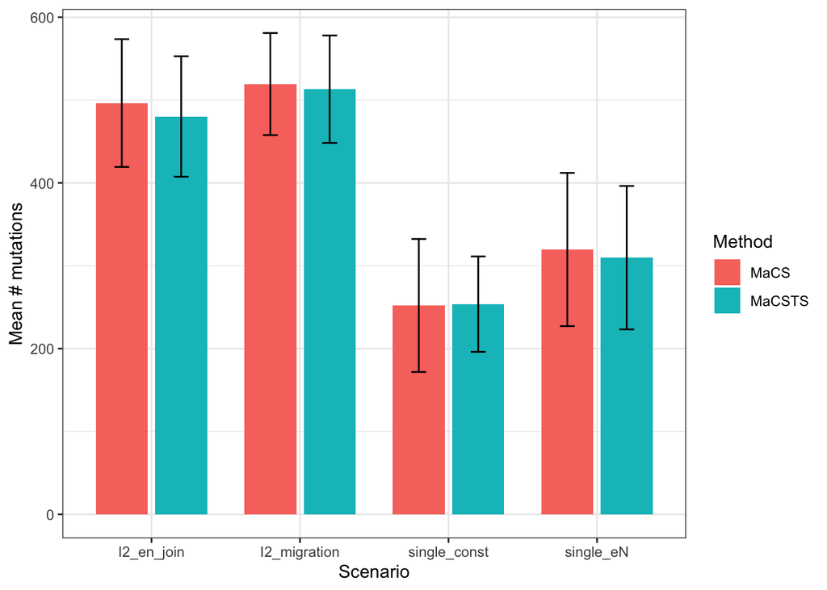

```r
library(dplyr)
library(tidyr)
library(ggplot2)
plot_df <- mut_stats %>%
    select(scenario, macs_mut_mean, macs_mut_sd, macsts_mut_mean, macsts_mut_sd) %>%
    pivot_longer(
        cols = -scenario,
        names_to = c("method", ".value"),
        names_pattern = "(macs|macsts)_mut_(mean|sd)"
    ) %>%
    mutate(method = recode(method, macs = "MaCS", macsts = "MaCSTS"))

ggplot(plot_df, aes(x = scenario, y = mean, fill = method)) +
    geom_col(position = position_dodge(width = 0.8), width = 0.7) +
    geom_errorbar(
        aes(ymin = mean - sd, ymax = mean + sd),
        position = position_dodge(width = 0.8),
        width = 0.2
    ) +
    labs(x = "Scenario", y = "Mean # mutations", fill = "Method") +
    theme_bw()
```

## Save Outputs

```r
manifest_csv_path <- file.path(outDir, "phase1_macsTS_useMacsMut_FALSE_manifest.csv")
status_csv_path <- file.path(outDir, "phase1_macsTS_useMacsMut_FALSE_run_status.csv")

write.csv(manifest_df, manifest_csv_path, row.names = FALSE)
write.csv(run_status_df, status_csv_path, row.names = FALSE)

cat("Saved manifest CSV:", manifest_csv_path, "\n")
```

```
## Saved manifest CSV: testData/out_phase1_useMacsMut_FALSE/phase1_macsTS_useMacsMut_FALSE_manifest.csv
```

```r
cat("Saved run status CSV:", status_csv_path, "\n")
```

```
## Saved run status CSV: testData/out_phase1_useMacsMut_FALSE/phase1_macsTS_useMacsMut_FALSE_run_status.csv
```

```r
if (writeTrees) {
  cat("Saved .trees files under:", outDir, "\n")
}
```

```
## Saved .trees files under: testData/out_phase1_useMacsMut_FALSE
```

## Next Step

Convert the parameters and use them to run simulations with msprime. Then we can compare the distributions on number of trees, edges, nodes, mutations and tree heights.